# CatBoost clean

Joshua Ewald

2023-10-27

Note: The main code doesn’t do gridsearch on catboost, it just uses the already found best results. Given this I included my code to give an indication of how that was found. If you want to go more in depth into that this should give an idea of how it was done.

Another note: catboost is not available on CRAN. To install it use: “install.packages(‘devtools’)” followed by: “devtools::install_url(‘https://github.com/catboost/catboost/releases/download/v1.2.2/catboost-R-Windows-1.2.2.tgz’, INSTALL_opts = c(”–no-multiarch”, “–no-test-load”))”

```r
library(caret)
library(tidyverse)
```

```r
library(dplyr)
library(catboost)
library(ggplot2)
library(PRROC)
library(pROC)
#Data should be in same directory as this code.
data <- read.csv("pulseOx_data.csv",header=TRUE)
```

Because Catboost is the slowest algorithm by a substantial margin (and because it uses data in a different format) its grid search was not run in the main code along with the other algorithms. This is a cleaned up version of my individual work which was used to find those results. Variations of this code were used with different parameters to test hyperparameters and compare their CV results to hone in on the best values (We did not use test results for this, despite those being found at the bottom of the code). This is not a full accounting of the work done but merely to demonstrate how it was done since that was not included in the main submitted code.

X is a random variable that was somehow added during an earlier step of preparing the data, We can ignore that. We also don’t want SaO2 since our purpose is to create a classifier which finds hidden hypoxemia the need to test SaO2 for everyone.

```r
data=select(data, -c(SaO2, X))
```

We then split this data into training and testing parts.

```r
set.seed(5003)
split=createDataPartition(data$hidden_hypoxemia,p=0.8,list=FALSE)
training0=data[split,]
testing0=data[-split,]
```

We then want to be able to apply the various imputation and sampling methods to the data and then perform a grid search to find the hyperparameters of the CatBoost which perform the best on this data.

There were three approaches considered for missing data. The first used median values from a normal human range. The second used distributions of values in this range. The third does not require an implementation since it is to not fill in missing values. This is an acceptable option for tree based methods such as Catboost.

```r
missing_value_1 <- function(data, mean_value = NULL){

  #use the mean of the training dataset to impute the missing value in the test dataset
  if (is.null(mean_value) == T){
      data$weight[is.na(data$weight)] <- mean(data$weight, na.rm = TRUE)
      data$height[is.na(data$height)] <- mean(data$height, na.rm = TRUE)
      data$BMI[is.na(data$BMI)] <- mean(data$BMI, na.rm = TRUE)
  } else {
      data$weight[is.na(data$weight)] <- mean_value[1]
      data$height[is.na(data$height)] <- mean_value[2]
      data$BMI[is.na(data$BMI)] <- mean_value[3]
  }


  data$sofa_liver[is.na(data$sofa_liver)] <- 0  #0 represents have no problem
  data$FiO2[is.na(data$FiO2)] <- 21 # standard
  data$sofa_resp[is.na(data$sofa_resp)] <- 0


  data$ck_mb[is.na(data$ck_mb)] <- 2.5  #0-5
  data$ck_cpk[data$gender == "F" & is.na(data$ck_cpk)] <- 109  #26 - 192
  data$ck_cpk[data$gender == "M" & is.na(data$ck_cpk)] <- 173.5 #39 - 308
  data$fibrinogen[is.na(data$fibrinogen)] <- 300 #200 - 400
  data$ld_ldh[is.na(data$ld_ldh)] <- 210    #140 - 280
  data$albumin[is.na(data$albumin)] <- 4.4  #3.4 - 5.4
  data$bilirubin_total[is.na(data$bilirubin_total)] <- 0.65   #0.1 - 1.2
  data$alp[is.na(data$alp)] <- 95.5  #44 - 147
  data$alt[is.na(data$alt)] <- 31.5      #7 - 56
  data$ast[is.na(data$ast)] <- 25      #10 - 40
  data$calcium[is.na(data$calcium)] <- 9.8  #8.5 - 10.5
  data$temperature[is.na(data$temperature)] <- 36.65   #36.1 - 37.2
  data$lactate[is.na(data$lactate)] <- 1.05   #0.5 - 1.6

  # Fill NA values in columns starting with "delta" with 0
  delta_columns <- grep("^delta", names(data), value = TRUE)
  data[, delta_columns] <- lapply(data[, delta_columns], function(col) ifelse(is.na(col), 0, col))

  # Drop rows with NA values
  remove_list <<- complete.cases(data)
  data_dropna <- data[complete.cases(data), ]
  return(data_dropna)
}
```

```r
missing_value_2 <- function(data, mean_value = NULL){
  #use the mean of the training dataset to impute the missing value in the test dataset
  if (is.null(mean_value) == T){
      data$weight[is.na(data$weight)] <- mean(data$weight, na.rm = TRUE)
      data$height[is.na(data$height)] <- mean(data$height, na.rm = TRUE)
      data$BMI[is.na(data$BMI)] <- mean(data$BMI, na.rm = TRUE)
  } else {
      data$weight[is.na(data$weight)] <- mean_value[1]
      data$height[is.na(data$height)] <- mean_value[2]
      data$BMI[is.na(data$BMI)] <- mean_value[3]
  }

  data$sofa_liver[is.na(data$sofa_liver)] <- 0  #0 represents have no problem
  data$FiO2[is.na(data$FiO2)] <- 21 # standard
  data$sofa_resp[is.na(data$sofa_resp)] <- 0

  set.seed(5003)
  data$ck_mb[is.na(data$ck_mb)] <- runif(sum(is.na(data$ck_mb)), 0, 5)

  female_na <- data$gender == "F" & is.na(data$ck_cpk)
  male_na <- data$gender == "M" & is.na(data$ck_cpk)
  data$ck_cpk[female_na] <- runif(sum(female_na), 26, 192)
  data$ck_cpk[male_na] <- runif(sum(male_na), 39, 308)

  data$fibrinogen[is.na(data$fibrinogen)] <- runif(sum(is.na(data$fibrinogen)), 200, 400)
  data$ld_ldh[is.na(data$ld_ldh)] <- runif(sum(is.na(data$ld_ldh)), 140, 280)
  data$albumin[is.na(data$albumin)] <- runif(sum(is.na(data$albumin)), 3.4, 5.4)
  data$bilirubin_total[is.na(data$bilirubin_total)] <- runif(sum(is.na(data$bilirubin_total)), 0.1, 1.2)
  data$alp[is.na(data$alp)] <- runif(sum(is.na(data$alp)), 44, 147)
  data$alt[is.na(data$alt)] <- runif(sum(is.na(data$alt)), 7, 56)
  data$ast[is.na(data$ast)] <- runif(sum(is.na(data$ast)), 10, 40)
  data$calcium[is.na(data$calcium)] <- runif(sum(is.na(data$calcium)), 8.5, 10.5)
  data$temperature[is.na(data$temperature)] <- runif(sum(is.na(data$temperature)), 36.1, 37.2)
  data$lactate[is.na(data$lactate)] <- runif(sum(is.na(data$lactate)), 0.5, 1.6)

  # Fill NA values in columns starting with "delta" with 0
  delta_columns <- grep("^delta", names(data), value = TRUE)
  data[, delta_columns] <- lapply(data[, delta_columns], function(col) ifelse(is.na(col), 0, col))

  # Drop rows with NA values
  data_dropna <- data[complete.cases(data), ]
  return(data_dropna)
}
```

Only one (explicit) balance method was considered here since SMOTE does not function effectively on categorical variables. There are some approaches to implement SMOTE on non numeric features but they are harder to use, not as well supported and not as effective in any case. This is likely not a concern since we saw that the SMOTE on the other tree based methods reduced their sensitivity to an unacceptable level for a medical context. We also considered not balancing the data (and simply relying on weighting in the model itself) but this was found to perform much worse.

```r
balance_method_1 <- function(data){
  set.seed(5003)
  data <- data %>% select(-subject_id)
  data_1 <- data %>% filter(hidden_hypoxemia == 1)
  data_0_sample <- data %>% filter(hidden_hypoxemia == 0) %>% sample_n(nrow(data_1))
  balanced_data <- rbind(data_1, data_0_sample)
  return(balanced_data)
}
```

Function to put the data in a form compatible with Catboost.

```r
Cat_prep <- function(inp_data,races=NULL){

  #The CatBoost takes categorical variables (character variables) as factors for the independent variables and uses an integer for the target.
  target=inp_data$hidden_hypoxemia
  vars=select(inp_data,-hidden_hypoxemia)
  vars = as.data.frame(lapply(vars, function(col) {
    if (is.character(col)) {
      return(as.factor(col))
    }
    return(col)
  }))
  target = as.integer(target)


  #Also race was specifically an issue since it needs to be a factor with the same levels in each case (and it has many options so some can be missed by sampling). races will be used as a parameter for the evaluation and testing data to make sure they have the right levels.
  if (is.factor(races) && length(levels(races)) > 0) {
    vars$race <- factor(vars$race, levels = levels(races))
  }

  #Put this in pool to use in CatBoost.
  pool <- catboost.load_pool(data = vars, label = target)

  return(pool)
}
```

Missing values. We used the commented line instead to not do any imputation.

```r
training = missing_value_1(training0)
#training=training0
```

Balancing data. Don’t run if you don’t want to use balancing.

```r
training = balance_method_1(training)
```

Put data in a pool so it can be used with Catboost.

```r
train_pool=Cat_prep(training)
```

We want to do a grid search with Catboost. Set this grid to include the values we want to search over.

```r
grid <- expand.grid(
  depth = c(3,5,8),
  learning_rate = c(0.004,0.02,0.1),
  l2_leaf_reg = c(0.002, 0.1, 5)
)
```

The reasoning for which hyperparameters to tune was something like: We already know that the oversampling methods produce bad results. So we know that our data will have about 2000 samples but over 100 variables. The lowish number of samples and high dimensionality of our data has an effect on our consideration of appropriate hyperparameters to tune over. The large number of features suggests that regularisation and depth will be important parameters, at the same time there are not many samples means that trees that are too deep introduce potential for overtuning which might not be properly controlled by regularisation. We also know that quite a few of our parameters are not of great importance for actually predicting the class, given these factors we will use a moderate range of tree depths (3-8). Given the small number of samples it is possible that introducing some randomness to the splits via random_strength could potentially help give us a more generalisable model. Of course the greater randomness of this would also recommend increasing the number of cross validation splits. This would be very computationally costly to do in the main cross validation so I will do mine in two steps, one with depth, learning rate and regularisation strength then another using the optimum parameters of that and tuning random_strength with more CV splits. As always we will include learning rate in the grid search. We got an idea of starting range from “Importance of Hyperparameters of Machine Learning Algorithms by Philipp Probst, Anne-Laure Boulesteix and Bernd Bisch”. For iterations we will use a large number and rely on regularisation to address overfitting and early stopping to limit runtime (and also limit overfitting).

Note: I didn’t want to ignore the code below entirely and I couldn’t find a convenient way to suppress the output but not the code. Just scroll through the following output, there isa much more readible version below. It does serve the purpose of highlighting why this was not carried out in the main code.

```r
results <- list()

#We set out weights for the classes to potentially help with unbalanced data (this will have no effect for the balanced cases).
training_targets=training$hidden_hypoxemia
class_counts <- table(training_targets)
total_samples <- sum(class_counts)
class_weights_vector <- total_samples / (2 * class_counts)
class_weights <- as.numeric(class_weights_vector)

for (i in 1:nrow(grid)) {
  current_params <- list(
    loss_function = 'Logloss',
    depth = grid$depth[i],
    learning_rate = grid$learning_rate[i],
    iterations = 1000,
    verbose = 200,
    class_weights = class_weights,
    od_type = 'Iter',
    od_wait = 20,
    l2_leaf_reg = grid$l2_leaf_reg[i]
  )

  cv_result = catboost.cv(
    pool = train_pool,
    params = current_params,
    fold_count = 3,  # 3-fold CV.
    partition_random_seed = 5003  # for reproducibility
  )

  # Training and validation accuracy
  train_accuracy = 1 - cv_result$train.Logloss.mean[length(cv_result$train.Logloss.mean)]
  test_accuracy = 1 - cv_result$test.Logloss.mean[length(cv_result$test.Logloss.mean)]

  results[[i]] <- list(
    params = current_params,
    train_accuracy = train_accuracy,
    test_accuracy = test_accuracy
  )
}
```

[output not shown]

[output cut: 624 more lines]

```
##
## bestTest = 0.4193462601
## bestIteration = 123
##
## Training on fold [1/3]
## 0:   learn: 0.6458077    test: 0.6560717 best: 0.6560717 (0) total: 59.7ms   remaining: 59.6s
##
## bestTest = 0.4471613738
## bestIteration = 103
##
## Training on fold [2/3]
## 0:   learn: 0.6546534    test: 0.6542291 best: 0.6542291 (0) total: 85.8ms   remaining: 1m 25s
##
## bestTest = 0.3888620387
## bestIteration = 162
```

We can get an easier to read version of the above which shows average results. We do this below. It also prints out the best combination at the bottom.

```r
# Extract the test accuracies to find the best parameters
test_accuracies <- sapply(results, function(x) x$test_accuracy)
best_params_index <- which.max(test_accuracies)
best_result <- results[[best_params_index]]

# Printing the results
for (i in 1:length(results)) {
  cat(paste0("Parameters: ", toString(results[[i]]$params),
             "\nTraining Accuracy: ", results[[i]]$train_accuracy,
             "\nTesting Accuracy: ", results[[i]]$test_accuracy, "\n\n"))
}
```

```
## Parameters: Logloss, 3, 0.004, 1000, 200, c(1, 1), Iter, 20, 0.002
## Training Accuracy: 0.567236723484412
## Testing Accuracy: 0.523493440762012
##
## Parameters: Logloss, 5, 0.004, 1000, 200, c(1, 1), Iter, 20, 0.002
## Training Accuracy: 0.681384327551534
## Testing Accuracy: 0.547133132267988
##
## Parameters: Logloss, 8, 0.004, 1000, 200, c(1, 1), Iter, 20, 0.002
## Training Accuracy: 0.881723527129017
## Testing Accuracy: 0.556910118578804
##
## Parameters: Logloss, 3, 0.02, 1000, 200, c(1, 1), Iter, 20, 0.002
## Training Accuracy: 0.736634529220748
## Testing Accuracy: 0.569448384199761
##
## Parameters: Logloss, 5, 0.02, 1000, 200, c(1, 1), Iter, 20, 0.002
## Training Accuracy: 0.769735288071411
## Testing Accuracy: 0.561304067153589
##
## Parameters: Logloss, 8, 0.02, 1000, 200, c(1, 1), Iter, 20, 0.002
## Training Accuracy: 0.917959073874153
## Testing Accuracy: 0.555856145268816
##
## Parameters: Logloss, 3, 0.1, 1000, 200, c(1, 1), Iter, 20, 0.002
## Training Accuracy: 0.747937203432829
## Testing Accuracy: 0.552370437154807
##
## Parameters: Logloss, 5, 0.1, 1000, 200, c(1, 1), Iter, 20, 0.002
## Training Accuracy: 0.823629088613981
## Testing Accuracy: 0.538909621640306
##
## Parameters: Logloss, 8, 0.1, 1000, 200, c(1, 1), Iter, 20, 0.002
## Training Accuracy: 0.924184271288118
## Testing Accuracy: 0.494150645912643
##
## Parameters: Logloss, 3, 0.004, 1000, 200, c(1, 1), Iter, 20, 0.1
## Training Accuracy: 0.561727930665969
## Testing Accuracy: 0.52353091272766
##
```

[output cut: 52 more lines]

```
## Parameters: Logloss, 8, 0.02, 1000, 200, c(1, 1), Iter, 20, 5
## Training Accuracy: 0.918710713647667
## Testing Accuracy: 0.58802095279006
##
## Parameters: Logloss, 3, 0.1, 1000, 200, c(1, 1), Iter, 20, 5
## Training Accuracy: 0.743170084091694
## Testing Accuracy: 0.572269058619674
##
## Parameters: Logloss, 5, 0.1, 1000, 200, c(1, 1), Iter, 20, 5
## Training Accuracy: 0.832833021785115
## Testing Accuracy: 0.576423037490189
##
## Parameters: Logloss, 8, 0.1, 1000, 200, c(1, 1), Iter, 20, 5
## Training Accuracy: 0.932075940496677
## Testing Accuracy: 0.57852565445614
```

```r
# Print best parameters and their accuracies
cat(paste0("Best Parameters: ", toString(best_result$params),
           "\nBest Training Accuracy: ", best_result$train_accuracy,
           "\nBest Testing Accuracy: ", best_result$test_accuracy))
```

```
## Best Parameters: Logloss, 8, 0.02, 1000, 200, c(1, 1), Iter, 20, 5
## Best Training Accuracy: 0.918710713647667
## Best Testing Accuracy: 0.58802095279006
```

This (should, in its original configuration) give a depth of 8, learning rate of 0.02 and regularisation coefficient of 5 as the optimum hyperparameters. If we look more closely at the results we can see that With a larger value for learning rate and smaller value for regularisation the models can suffer from overfitting but that is not an issue with this combination of learning rate and regulrisation so we will use the deeper tree despite the small increase in accuracy that this gives. As noted earlier this (and the below section) was used repeatedly to investigate different combinations of data treatment and hyperparameters and ultimately gave the combinations used in the main code.

We then test the best combination of hyperparamters with different tree split randomness values (the default is 1).

```r
grid <- expand.grid(
  random_strength = c(1,4,7,10)
)
```

```r
results2 <- list()

training_targets=training$hidden_hypoxemia
class_counts <- table(training_targets)
total_samples <- sum(class_counts)
class_weights_vector <- total_samples / (2 * class_counts)
class_weights <- as.numeric(class_weights_vector)

for (i in 1:nrow(grid)) {
  current_params = list(
    loss_function = 'Logloss',
    depth = 8,
    learning_rate = 0.02,
    iterations = 1000,
    verbose = 200,
    random_strength = grid$random_strength[i],
    class_weights = class_weights,
    od_type = 'Iter',
    od_wait = 20,
    l2_leaf_reg = 5
  )

  cv_result <- catboost.cv(
    pool = train_pool,
    params = current_params,
    fold_count = 3,  # 3-fold CV.
    partition_random_seed = 5003  # for reproducibility
  )

  # Calculate training and validation accuracy
  train_accuracy = 1 - cv_result$train.Logloss.mean[length(cv_result$train.Logloss.mean)]
  test_accuracy = 1 - cv_result$test.Logloss.mean[length(cv_result$test.Logloss.mean)]

  results2[[i]] = list(
    params = current_params,
    train_accuracy = train_accuracy,
    test_accuracy = test_accuracy
  )
}
```

[output not shown]

[output cut: 58 more lines]

```
## 600: learn: 0.1613342    test: 0.4540378 best: 0.4540378 (600)   total: 39.2s    remaining: 26s
##
## bestTest = 0.4401628777
## bestIteration = 764
##
## Training on fold [2/3]
## 0:   learn: 0.6922948    test: 0.6927146 best: 0.6927146 (0) total: 86.5ms   remaining: 1m 26s
## 200: learn: 0.4429556    test: 0.5453612 best: 0.5453551 (199)   total: 12.8s    remaining: 50.9s
## 400: learn: 0.3211680    test: 0.4965056 best: 0.4965056 (400)   total: 26.5s    remaining: 39.6s
## 600: learn: 0.1730896    test: 0.4155745 best: 0.4155745 (600)   total: 40.8s    remaining: 27.1s
## 800: learn: 0.0971129    test: 0.3954999 best: 0.3954999 (800)   total: 54.1s    remaining: 13.4s
## 999: learn: 0.0609111    test: 0.3866044 best: 0.3865516 (998)   total: 1m 7s    remaining: 0us
##
## bestTest = 0.3865515643
## bestIteration = 998
```

```r
# Extract the test accuracies to find the best parameters
test_accuracies <- sapply(results2, function(x) x$test_accuracy)
best_params_index <- which.max(test_accuracies)
best_result <- results2[[best_params_index]]

# Printing the results
for (i in 1:length(results2)) {
  cat(paste0("Parameters: ", toString(results2[[i]]$params),
             "\nTraining Accuracy: ", results2[[i]]$train_accuracy,
             "\nTesting Accuracy: ", results2[[i]]$test_accuracy, "\n\n"))
}
```

```
## Parameters: Logloss, 8, 0.02, 1000, 200, 1, c(1, 1), Iter, 20, 5
## Training Accuracy: 0.918710713647667
## Testing Accuracy: 0.58802095279006
##
## Parameters: Logloss, 8, 0.02, 1000, 200, 4, c(1, 1), Iter, 20, 5
## Training Accuracy: 0.925491885120578
## Testing Accuracy: 0.584869810751007
##
## Parameters: Logloss, 8, 0.02, 1000, 200, 7, c(1, 1), Iter, 20, 5
## Training Accuracy: 0.911139683976229
## Testing Accuracy: 0.581226517768874
##
## Parameters: Logloss, 8, 0.02, 1000, 200, 10, c(1, 1), Iter, 20, 5
## Training Accuracy: 0.923380178940498
## Testing Accuracy: 0.585346068505705
```

```r
# Print best parameters and their accuracies
cat(paste0("Best Parameters: ", toString(best_result$params),
           "\nBest Training Accuracy: ", best_result$train_accuracy,
           "\nBest Testing Accuracy: ", best_result$test_accuracy))
```

```
## Best Parameters: Logloss, 8, 0.02, 1000, 200, 1, c(1, 1), Iter, 20, 5
## Best Training Accuracy: 0.918710713647667
## Best Testing Accuracy: 0.58802095279006
```

Unfortunately this did not seem to improve performance. We will not use it in our final model.

DO NOT FEEL THE NEED TO READ BELOW THIS IF YOU ARE SHORT ON TIME. Now that we have decided on the best model we will look at some more performance metrics on that model with chosen data and hyperparameters. This was not part of choosing hyperparameters but I figured I would leave it in, this is the appendix after all. This has a little bit on an issue with validation data used in CV vs used for prediction (with early stopping) and shows where the lift graph stuff originally comes from (with, I think, much better explanation) but as I said do not feel the need to read this if you are short on time (although that could really apply to the whole appendix code thing).

First set out the data.

```r
training = missing_value_1(training0)
testing = missing_value_1(testing0,mean_value=c(mean(training$weight),mean(training$height),mean(training$BMI)))
```

```r
training = balance_method_1(training)
```

There is somewhat of a dilemma involving validation data. Generally we would do cross validation with validation sets split off the training data and then train the model found on the entire training set. In this case however validation data is still required for the early stopping of the Catboost. We can’t use the same split as was used in the CV since that was the average of multiple different models with different splits. Ultimately I don’t think it is a serious concern, the point after all is to get the most generally effective parameters so a different set of validation data for the training shouldn’t be too problematic.

```r
val_split=createDataPartition(training$hidden_hypoxemia,p=0.8,list=FALSE)
train_train=training[val_split,]
train_val=training[-val_split,]
```

Will use levels of race categorical variable in training to set levels in other data. Anything else will be considered as an NA.

```r
races=levels(train_train$race)
```

```r
train_pool=Cat_prep(train_train)
eval_pool=Cat_prep(train_val,races)
test_pool=Cat_prep(testing,races)
```

```r
training_targets=training$hidden_hypoxemia
class_counts <- table(training_targets)
total_samples <- sum(class_counts)
class_weights_vector <- total_samples / (2 * class_counts)
class_weights <- as.numeric(class_weights_vector)

params <- list(
  loss_function = 'Logloss', # Binary classification
  depth = 8,
  learning_rate = 0.02,
  iterations = 1000, # Increase iterations
  verbose = 100,
  class_weights = class_weights,
  od_type = 'Iter', # Use early stopping to prevent overfitting
  od_wait = 20,
  l2_leaf_reg = 5
)

model <- catboost.train(train_pool, params = params, test_pool = eval_pool)
```

```
## 0:   learn: 0.6843555    test: 0.6856023 best: 0.6856023 (0) total: 59.3ms   remaining: 59.3s
## 100: learn: 0.3725838    test: 0.4843615 best: 0.4843615 (100)   total: 7.02s    remaining: 1m 2s
## 200: learn: 0.2812289    test: 0.4608779 best: 0.4608779 (200)   total: 15.4s    remaining: 1m 1s
## 300: learn: 0.2193697    test: 0.4525123 best: 0.4524526 (299)   total: 22.6s    remaining: 52.5s
## 400: learn: 0.1728594    test: 0.4464796 best: 0.4464411 (399)   total: 29.9s    remaining: 44.6s
## 500: learn: 0.1336148    test: 0.4417657 best: 0.4415106 (493)   total: 37.2s    remaining: 37s
## Stopped by overfitting detector  (20 iterations wait)
##
## bestTest = 0.4389066647
## bestIteration = 567
##
## Shrink model to first 568 iterations.
```

```r
#Getting predicted probabilities and classes using our model
predictions <- catboost.predict(model, test_pool, prediction_type = "Probability")
predicted_classes <- ifelse(predictions > 0.5, 1, 0)

#For some reason R sorts the target options alphabetically which mean that some of our result metrics were originally for the models ability to correctly classify people who don't have hidden hypoxemia which is much less important than those who do. So we make the predictions an ordered factor variable.
test_target=testing$hidden_hypoxemia
test_target = factor(test_target, levels = c(1, 0))
predicted_classes <- factor(predicted_classes, levels = c(1, 0))

confusion_mtx2 = confusionMatrix(predicted_classes, test_target, mode="everything")
confusion_mtx2
```

```
## Confusion Matrix and Statistics
##
##           Reference
## Prediction     1     0
##          1   215  2380
##          0    64 11054
##
##                Accuracy : 0.8218
##                  95% CI : (0.8153, 0.8281)
##     No Information Rate : 0.9797
##     P-Value [Acc > NIR] : 1
##
##                   Kappa : 0.1172
##
##  Mcnemar's Test P-Value : <2e-16
##
##             Sensitivity : 0.77061
##             Specificity : 0.82284
##          Pos Pred Value : 0.08285
##          Neg Pred Value : 0.99424
##               Precision : 0.08285
##                  Recall : 0.77061
##                      F1 : 0.14962
##              Prevalence : 0.02035
##          Detection Rate : 0.01568
##    Detection Prevalence : 0.18924
##       Balanced Accuracy : 0.79672
##
##        'Positive' Class : 1
##
```

We can also get a few more potentially useful metrics.

Matthews Correlation Coefficient (MCC):

```r
cm <- confusion_mtx2$table

TP <- as.numeric(cm[1, 1])
TN <- as.numeric(cm[2, 2])
FP <- as.numeric(cm[2, 1])
FN <- as.numeric(cm[1, 2])

mcc_calculated <- (TP * TN - FP * FN) / sqrt((TP + FP) * (TP + FN) * (TN + FP) * (TN + FN))
print(mcc_calculated)
```

```
## [1] 0.213897
```

Not a great value but not unexpected given the difficulty of the data.

We can do a lift plot like so:

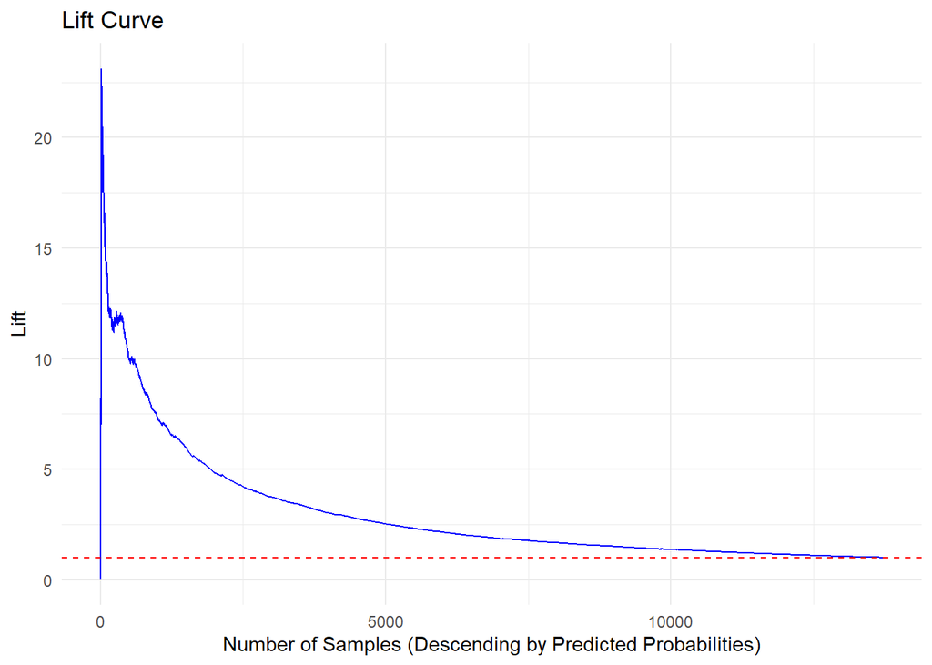

```r
#Needs the targets to be numeric. (note the conversion to characters first, if it went straight from factors it would just assign each a number, so the first class "1" would be given 1 and the class "0" would be given 2. With characters though the as_numeric works as_expected)
test_target_numeric <- as.numeric(as.character(test_target))

#This sets up the data for the lift plot. The first line takes a dataframe of the test targets and predicted probabilities and sorts them in descending order by the prediction probabilities (so the most confident predictions are first). The next line takes the cumulative sum of actual positive cases, the number of instances of hidden hypoxemia we are finding, starting from our predicted most likely cases. The next line is the number we would expect to find in that many samples is we picked randomly (it is the number of hidden hypoxemia cases divided by total number of samples). Finally we calculate lift by dividing the cumulative_actuals by the expected_positives.
lift_data <- data.frame(test_target_numeric, predictions) %>%
  arrange(desc(predictions)) %>%
  mutate(cumulative_actuals = cumsum(test_target_numeric),
         expected_positives = row_number() * (sum(test_target_numeric) / n()),
         lift = cumulative_actuals / expected_positives)

num_rows <- nrow(lift_data)

# Plot using ggplot2
ggplot(lift_data, aes(x = seq_len(num_rows), y = lift)) +
  geom_line(color = "blue") +
  geom_hline(yintercept = 1, color = "red", linetype = "dashed") +
  labs(title = "Lift Curve",
       x = "Number of Samples (Descending by Predicted Probabilities)",
       y = "Lift") +
  theme_minimal()
```

This is effective for showing how much better the model is than random guessing for its most confident predictions. Since in a medical context we don’t want to perform too many follow up tests for hidden hypoxemia looking at the most confident predictions is a good way of getting the value of the model without expending too many resources. As we would expect the model does well with its most confident predictions but not so much with its less confident ones. To really get value out of this we will want to compare to similar plots for the other potential models.

To look at a more common graph we can also create an ROC curve.

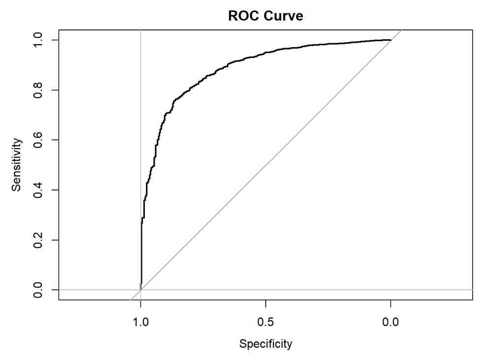

```r
roc_obj <- roc(response = test_target, predictor = predictions, positive="1", quiet=TRUE)
plot(roc_obj, main="ROC Curve")
abline(h=0, v=1, col="gray")
```

```r
auc(roc_obj)
```

```
## Area under the curve: 0.8832
```

This does show good performance and the area under the curve is high but unlike with the lift graph much of this good result is classification of the negative class which we don’t really care about very much.

Finally since it is useful to aid understanding in a clinical sense we can look at the feature importance provided by the best model.

```r
# Feature importance
feature_importances <- catboost.get_feature_importance(model, train_pool, type='FeatureImportance')
names(feature_importances) <- names(training)[-which(names(training) == "hidden_hypoxemia")]
ordered_importances=feature_importances[order(-feature_importances)]
imp_20=head(ordered_importances,20)

importance_df=data.frame(
  feature=names(imp_20),
  importance=imp_20
)
```

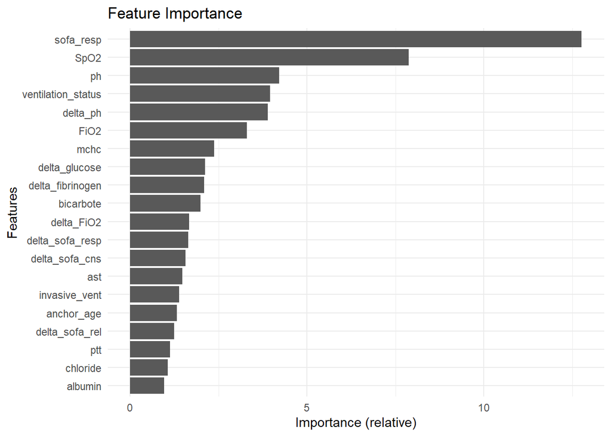

```r
ggplot(importance_df, aes(x = reorder(feature, importance), y = importance)) +
  geom_bar(stat = "identity") +
  coord_flip() +
  labs(title = "Feature Importance", x = "Features", y = "Importance (relative)") +
  theme_minimal()
```

A true analysis of the features found to be importance would require far more domain knowledge than we possess but this does highlight the models use of generally respiration focused measures to make its predictions. From further reading I am somewhat concerned that the SOFA score for respiration might involve using data which could only be found using blood gas analysis. If there is another related measure which the model has discovered can be used to approximate SaO2 and therefore cases of hidden hypoxemia that is great but if it requires BGA to obtain then you might as well just look directly at SaO2 and the model is irrelevent. Deep domain knowledge could help a great deal in selecting which variables to use and which not to use and in assessing the actual value of this models predictions. Unfortunately that is outside the scope of this assignment.